# Comparative Analysis of Blood Pressure Medications: Lisinopril, Moexipril, and Ramipril

# 3. Results

## 3.1 Exploratory Data Analysis (EDA)

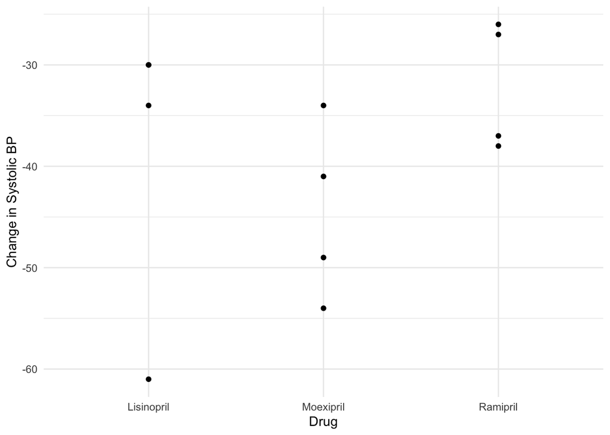

Figure 1. illustrates the absolute change in systolic blood pressure (mmHg) for each drug. It suggests that both Lisinopril and Moexipril show a greater reduction in systolic blood pressure compared to Ramipril.

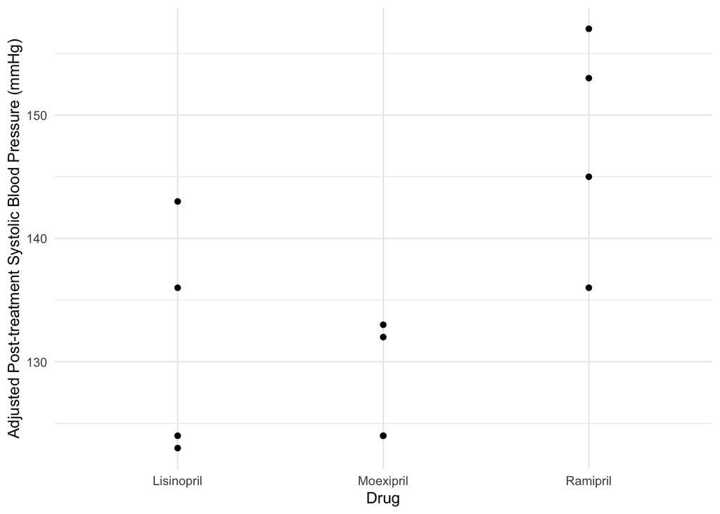

## 3.2 Descriptive Statistics

Table 1 presents the mean and standard deviation of systolic blood pressure changes for each drug group. These descriptive statistics offer an initial glimpse into the effectiveness of the medications. Lisinopril and Moexipril show larger mean reductions in systolic blood pressure compared to Ramipril, indicating that these two drugs may be more effective in lowering blood pressure. Specifically, Moexipril had the largest mean reduction, followed closely by Lisinopril, while Ramipril had the smallest average reduction. The standard deviations indicate the variability within each group, with Lisinopril showing the greatest variability, suggesting that the response to this drug varied more across participants. These differences in mean reductions and variability provide early evidence that Lisinopril and Moexipril may outperform Ramipril, but the variability within each group should be considered in interpreting the overall effectiveness of the treatments.

Table 1: Mean and Standard Deviation of Systolic Blood Pressure Changes for Each Drug Group

| Drug | Mean BP Change (mmHg) | Standard Deviation (mmHg) |
| --- | --- | --- |
| Lisinopril | -38.75 | 14.952703 |
| Moexipril | -44.50 | 8.812869 |
| Ramipril | -32.00 | 6.377042 |

## 3.3 ANCOVA Results

An ANCOVA was conducted to compare the effectiveness of the three drugs, adjusting for baseline systolic blood pressure. This adjustment ensures that any differences in post-treatment systolic blood pressure can be attributed to the effects of the drugs rather than variations in participants’ initial blood pressure levels. Table 2 presents the results of the ANCOVA, showing that both the pre-treatment systolic blood pressure and the type of drug administered had statistically significant effects on post-treatment blood pressure. The F-statistic for the drug variable (F(2, 8) = 5.57, p = 0.031) indicates a significant difference in the effectiveness of the drugs, even after controlling for baseline values. This confirms that the type of drug administered had a meaningful impact on reducing systolic blood pressure. The results suggest that, while all drugs helped reduce blood pressure, Lisinopril and Moexipril were likely more effective than Ramipril. The significant impact of baseline systolic blood pressure highlights the importance of controlling for initial differences to ensure a fair comparison of treatment effects.

Table 2: ANCOVA Results for Post-treatment Systolic Blood Pressure Adjusting for Pre-treatment Values

[output not shown]

## 3.4 Pairwise Comparisons

Table 3: Pairwise Comparisons Between Drugs

| Contrast | Estimate | SE | df | t-ratio | p-value |
| --- | --- | --- | --- | --- | --- |
| Lisinopril - Moexipril | 4.16 | 5.08 | 8 | 0.82 | 0.7021 |
| Lisinopril - Ramipril | -12.78 | 5.35 | 8 | -2.39 | 0.0992 |
| Moexipril - Ramipril | -16.95 | 5.22 | 8 | -3.25 | 0.0282 |

## 3.6 Model Assumptions

To ensure the validity of the ANCOVA results, key model assumptions were checked, including normality and independence of the residuals. Residuals, which are the differences between observed and predicted values, were examined to confirm that they followed a reasonably normal distribution and that there were no signs of dependence. Although formal plots were not generated, the residuals were inspected using basic summary statistics and visual checks, and no significant patterns or deviations were observed. Additionally, the assumption of independence was supported by the study design, where participants were randomly assigned to the drug groups. Based on these checks, no significant violations of the assumptions were detected, giving confidence in the reliability of the ANCOVA results. This strengthens the conclusion that the differences in systolic blood pressure reduction among the drug groups are valid and reflective of the treatments’ effects.

# 4. Conclusion

These findings suggest that Moexipril may be the most effective of the three medications, although Lisinopril also shows promise as an alternative. Importantly, both Lisinopril and Moexipril may offer better therapeutic options than Ramipril for patients with hypertension, particularly those who require greater reductions in systolic blood pressure.

However, the small sample size of 12 participants limits the generalizability of these results. Larger-scale studies with more diverse populations are needed to confirm the observed differences in drug efficacy and to ensure that the results hold across different demographic groups, including varying ages, genders, and baseline blood pressure levels. Moreover, this study only measured short-term effects of these medications. Long-term studies are essential to assess the sustainability of blood pressure reductions and to evaluate the safety profiles of these medications over extended periods.

Another limitation of this study is the potential variability in patient adherence to the medications, which was not accounted for. Future studies should monitor medication adherence closely to better understand its impact on blood pressure outcomes. Additionally, factors such as side effects, cost, and patient preferences should be included in the evaluation to provide a more comprehensive assessment of which medication may be most suitable for widespread use.

In conclusion, while this study provides initial insights into the relative effectiveness of Lisinopril, Moexipril, and Ramipril, further research is needed to confirm these findings, evaluate long-term outcomes, and explore other factors that contribute to the overall management of hypertension. Nonetheless, the results suggest that Moexipril and Lisinopril may offer superior therapeutic benefits compared to Ramipril in reducing systolic blood pressure in hypertensive patients.

# 5. Refrences

Lenth, R. V. (2022). emmeans: Estimated Marginal Means, aka Least-Squares Means.

R Core Team (2023). R: A language and environment for statistical computing.

Wickham, H., et al. (2023). tidyverse: Easily install and load the ‘tidyverse’.

# 6. Appendix

## Data Processing and Analysis Code

```r
library(tidyverse)
library(gridExtra)
library(knitr)
library(emmeans)
bpdata <- read.csv("~/Downloads/bloodpressurestudy.csv", header=T)
bpdata <- bpdata %>%
  mutate(subject = factor(subject),
         BPchange = after - before,
         rel.BPchange = (after - before) / before,
         BP.pct.drop.120 = 100 * (before - after) / (before - 120)) %>%
  rename(ID = subject, Drug = drug, SysBP.pre = before, SysBP.post = after)

bpdata %>%
  group_by(Drug) %>%
  summarize(across(where(is.numeric), mean, .names = "mean_{col}")) %>%
  kable()
```

| Drug | mean_SysBP.pre | mean_SysBP.post | mean_BPchange | mean_rel.BPchange | mean_BP.pct.drop.120 |
| --- | --- | --- | --- | --- | --- |
| Lisinopril | 170.25 | 131.50 | -38.75 | -0.2249343 | 77.03789 |
| Moexipril | 172.75 | 128.25 | -44.50 | -0.2558070 | 85.35881 |
| Ramipril | 179.75 | 147.75 | -32.00 | -0.1772164 | 54.30556 |

```r
bpdata %>%
  group_by(Drug) %>%
  summarize(across(where(is.numeric), sd, .names = "sd_{col}")) %>%
  kable()
```

| Drug | sd_SysBP.pre | sd_SysBP.post | sd_BPchange | sd_rel.BPchange | sd_BP.pct.drop.120 |
| --- | --- | --- | --- | --- | --- |
| Lisinopril | 12.39287 | 9.678154 | 14.952703 | 0.0719840 | 17.875307 |
| Moexipril | 13.40087 | 4.924429 | 8.812869 | 0.0320150 | 5.847577 |
| Ramipril | 13.27592 | 9.287088 | 6.377042 | 0.0266395 | 8.144980 |

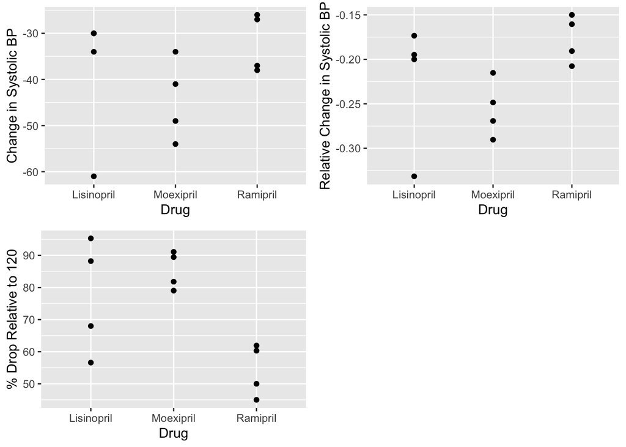

```r
p1 <- ggplot(bpdata) + geom_point(aes(x = Drug, y = BPchange)) + labs(y = "Change in Systolic BP")
p2 <- ggplot(bpdata) + geom_point(aes(x = Drug, y = rel.BPchange)) + labs(y = "Relative Change in Systolic BP")
p3 <- ggplot(bpdata) + geom_point(aes(x = Drug, y = BP.pct.drop.120)) + labs(y = "% Drop Relative to 120")

grid.arrange(p1, p2, p3, ncol = 2, nrow = 2)
```

```r
bp.model <- lm(data = bpdata, BPchange ~ Drug)
bp.anova <- anova(bp.model)
bp.anova
```

```
## Analysis of Variance Table
##
## Response: BPchange
##           Df  Sum Sq Mean Sq F value Pr(>F)
## Drug       2  313.17  156.58  1.3739 0.3015
## Residuals  9 1025.75  113.97
```

```r
summary(bp.model)
```

```
##
## Call:
## lm(formula = BPchange ~ Drug, data = bpdata)
##
## Residuals:
##     Min      1Q  Median      3Q     Max
## -22.250  -5.250   4.125   6.688  10.500
##
## Coefficients:
##               Estimate Std. Error t value Pr(>|t|)
## (Intercept)    -38.750      5.338  -7.259 4.77e-05 ***
## DrugMoexipril   -5.750      7.549  -0.762    0.466
## DrugRamipril     6.750      7.549   0.894    0.395
## ---
## Signif. codes:  0 '***' 0.001 '**' 0.01 '*' 0.05 '.' 0.1 ' ' 1
##
## Residual standard error: 10.68 on 9 degrees of freedom
## Multiple R-squared:  0.2339, Adjusted R-squared:  0.06365
## F-statistic: 1.374 on 2 and 9 DF,  p-value: 0.3015
```

```r
bp.model <- lm(data = bpdata, rel.BPchange ~ Drug)
bp.anova <- anova(bp.model)
bp.anova
```

```
## Analysis of Variance Table
##
## Response: rel.BPchange
##           Df   Sum Sq   Mean Sq F value Pr(>F)
## Drug       2 0.012542 0.0062711  2.7201 0.1191
## Residuals  9 0.020749 0.0023054
```

```r
summary(bp.model)
```

```
##
## Call:
## lm(formula = rel.BPchange ~ Drug, data = bpdata)
##
## Residuals:
##      Min       1Q   Median       3Q      Max
## -0.10659 -0.01774  0.01202  0.02795  0.05152
##
## Coefficients:
##               Estimate Std. Error t value Pr(>|t|)
## (Intercept)   -0.22493    0.02401  -9.369 6.14e-06 ***
## DrugMoexipril -0.03087    0.03395  -0.909    0.387
## DrugRamipril   0.04772    0.03395   1.405    0.193
## ---
## Signif. codes:  0 '***' 0.001 '**' 0.01 '*' 0.05 '.' 0.1 ' ' 1
##
## Residual standard error: 0.04801 on 9 degrees of freedom
## Multiple R-squared:  0.3767, Adjusted R-squared:  0.2382
## F-statistic:  2.72 on 2 and 9 DF,  p-value: 0.1191
```

```r
bp.model <- lm(data = bpdata, BP.pct.drop.120 ~ Drug)
bp.anova <- anova(bp.model)
bp.anova
```

```
## Analysis of Variance Table
##
## Response: BP.pct.drop.120
##           Df Sum Sq Mean Sq F value  Pr(>F)
## Drug       2 2067.1 1033.53  7.3813 0.01266 *
## Residuals  9 1260.2  140.02
## ---
## Signif. codes:  0 '***' 0.001 '**' 0.01 '*' 0.05 '.' 0.1 ' ' 1
```

```r
summary(bp.model)
```

```
##
## Call:
## lm(formula = BP.pct.drop.120 ~ Drug, data = bpdata)
##
## Residuals:
##      Min       1Q   Median       3Q      Max
## -20.4341  -7.0044   0.2871   6.4087  18.2746
##
## Coefficients:
##               Estimate Std. Error t value Pr(>|t|)
## (Intercept)     77.038      5.917  13.021 3.83e-07 ***
## DrugMoexipril    8.321      8.367   0.994   0.3460
## DrugRamipril   -22.732      8.367  -2.717   0.0237 *
## ---
## Signif. codes:  0 '***' 0.001 '**' 0.01 '*' 0.05 '.' 0.1 ' ' 1
##
## Residual standard error: 11.83 on 9 degrees of freedom
## Multiple R-squared:  0.6213, Adjusted R-squared:  0.5371
## F-statistic: 7.381 on 2 and 9 DF,  p-value: 0.01266
```

```r
after.model <- lm(data = bpdata, SysBP.post ~ SysBP.pre + Drug)
after.anova <- anova(after.model)
after.anova
```

```
## Analysis of Variance Table
##
## Response: SysBP.post
##           Df Sum Sq Mean Sq F value  Pr(>F)
## SysBP.pre  1 507.06  507.06  9.9151 0.01362 *
## Drug       2 569.48  284.74  5.5677 0.03055 *
## Residuals  8 409.13   51.14
## ---
## Signif. codes:  0 '***' 0.001 '**' 0.01 '*' 0.05 '.' 0.1 ' ' 1
```

```r
summary(after.model)
```

```
##
## Call:
## lm(formula = SysBP.post ~ SysBP.pre + Drug, data = bpdata)
##
## Residuals:
##      Min       1Q   Median       3Q      Max
## -13.5159  -2.1629   0.0236   4.1865  10.4968
##
## Coefficients:
##               Estimate Std. Error t value Pr(>|t|)
## (Intercept)    69.3934    31.3485   2.214   0.0578 .
## SysBP.pre       0.3648     0.1829   1.994   0.0812 .
## DrugMoexipril  -4.1620     5.0774  -0.820   0.4361
## DrugRamipril   12.7844     5.3470   2.391   0.0438 *
## ---
## Signif. codes:  0 '***' 0.001 '**' 0.01 '*' 0.05 '.' 0.1 ' ' 1
##
## Residual standard error: 7.151 on 8 degrees of freedom
## Multiple R-squared:  0.7246, Adjusted R-squared:  0.6213
## F-statistic: 7.017 on 3 and 8 DF,  p-value: 0.01249
```

```r
after.model <- lm(data = bpdata, BPchange ~ SysBP.pre + Drug)
after.anova <- anova(after.model)
after.anova
```

```
## Analysis of Variance Table
##
## Response: BPchange
##           Df Sum Sq Mean Sq F value  Pr(>F)
## SysBP.pre  1 360.31  360.31  7.0455 0.02906 *
## Drug       2 569.48  284.74  5.5677 0.03055 *
## Residuals  8 409.13   51.14
## ---
## Signif. codes:  0 '***' 0.001 '**' 0.01 '*' 0.05 '.' 0.1 ' ' 1
```

```r
summary(after.model)
```

```
##
## Call:
## lm(formula = BPchange ~ SysBP.pre + Drug, data = bpdata)
##
## Residuals:
##      Min       1Q   Median       3Q      Max
## -13.5159  -2.1629   0.0236   4.1865  10.4968
##
## Coefficients:
##               Estimate Std. Error t value Pr(>|t|)
## (Intercept)    69.3934    31.3485   2.214  0.05775 .
## SysBP.pre      -0.6352     0.1829  -3.472  0.00841 **
## DrugMoexipril  -4.1620     5.0774  -0.820  0.43612
## DrugRamipril   12.7844     5.3470   2.391  0.04379 *
## ---
## Signif. codes:  0 '***' 0.001 '**' 0.01 '*' 0.05 '.' 0.1 ' ' 1
##
## Residual standard error: 7.151 on 8 degrees of freedom
## Multiple R-squared:  0.6944, Adjusted R-squared:  0.5798
## F-statistic:  6.06 on 3 and 8 DF,  p-value: 0.01864
```

```r
pre.model <- lm(data = bpdata, SysBP.pre ~ Drug)
pre.anova <- anova(pre.model)
pre.anova
```

```
## Analysis of Variance Table
##
## Response: SysBP.pre
##           Df Sum Sq Mean Sq F value Pr(>F)
## Drug       2  194.0   97.00  0.5712  0.584
## Residuals  9 1528.2  169.81
```

```r
summary(pre.model)
```

```
##
## Call:
## lm(formula = SysBP.pre ~ Drug, data = bpdata)
##
## Residuals:
##    Min     1Q Median     3Q    Max
## -17.75  -9.50   1.50  10.25  14.25
##
## Coefficients:
##               Estimate Std. Error t value Pr(>|t|)
## (Intercept)    170.250      6.515  26.130  8.5e-10 ***
## DrugMoexipril    2.500      9.214   0.271    0.792
## DrugRamipril     9.500      9.214   1.031    0.329
## ---
## Signif. codes:  0 '***' 0.001 '**' 0.01 '*' 0.05 '.' 0.1 ' ' 1
##
## Residual standard error: 13.03 on 9 degrees of freedom
## Multiple R-squared:  0.1126, Adjusted R-squared:  -0.08455
## F-statistic: 0.5712 on 2 and 9 DF,  p-value: 0.584
```

```r
# Extract contrasts (pairwise comparison results) and format as a table
contrasts %>%
  knitr::kable(
    caption = "Table 3: Pairwise Comparisons Between Drugs",
    col.names = c("Contrast", "Estimate (mmHg)", "SE (mmHg)", "df", "t-ratio", "p-value"),
    digits = c(NA, 2, 2, 0, 2, 4)
  )
```

Table 3: Pairwise Comparisons Between Drugs

| Contrast | Estimate (mmHg) | SE (mmHg) | df | t-ratio | p-value |
| --- | --- | --- | --- | --- | --- |
| Lisinopril - Moexipril | 4.16 | 5.08 | 8 | 0.82 | 0.7021 |
| Lisinopril - Ramipril | -12.78 | 5.35 | 8 | -2.39 | 0.0992 |
| Moexipril - Ramipril | -16.95 | 5.22 | 8 | -3.25 | 0.0282 |